# R Notes on Classification, Clustering, etc.

Luisa M. Mimmi

Last run: September 29, 2019

## Set up

```
##
##  /var/folders/0b/3s7cbr4d2kvft0fl2nkpqkdm0000gn/T//RtmprANpCH/downloaded_packages
```

# CLASSIFICATION

Assign an observation to the “class” where it belongs:

NOTES: - (*) *typically not useful for understanding the nature of teh relationship between the feature and class outcome (aka the sign), but can be very effective as “black box”prediction engines"* - (*) *closely depends on available variables*

TYPES

- **SUPERVISED**: I DO have the actual “label”
  - criterion become *accuracy* of the prediction
- **UNSUPERVISED**: I don’t have the actual “label”
  - criterion (to shape groups) become *similarity*

Examples:

- spam filter
- genetic testing
- fraud detection
- psicological diagnosis

ALGORITHMs:

- K-nn ( Find the number of cases in the multidimensional space that are closest to the new one)
- k-means
- Decision trees
- Random forest
- Naive Bayes (start prior probability (eg of having cancer) then naive Bayes adjusts the probability - posterior probability- with each new piece of information, )
- SVM
- ANN (are multiple layers of equations and weights to model nonlinear outcomes)
- Logistic regression

### k-Nearest-Neighbors (kNN) CLASSIFICATION

NOTES: - (*) *“Closest” usually is defined by Euclidean distance (OF for quantitative features) in feature space* - (*) *You typically first standardize each feature to have mean =0 and variance =1 in the training sample* - (*) *The Nearest-Neighbors technique can also be used in regressoin and works reasonably well for low-dimensional problems. Instead, with high-dimensional features, the bias-variance tradeoff does not work in regr as it does in classificationo*

#### 1/2) Example Credit Default data - using `class::knn`

> colnames(df) [1] “ID” “LIMIT_BAL” “SEX” “EDUCATION” “MARRIAGE” “AGE” “PAY_0” “PAY_2” “PAY_3” “PAY_4”  
> [11] “PAY_5” “PAY_6” “BILL_AMT1” “BILL_AMT2” “BILL_AMT3” “BILL_AMT4” “BILL_AMT5” “BILL_AMT6” “PAY_AMT1” “PAY_AMT2” [21] “PAY_AMT3” “PAY_AMT4” “PAY_AMT5” “PAY_AMT6” “DEFAULT”

```r
# DM_04_03.R

# LOAD PACKAGES ############################################
pacman::p_load("class")  # class has knn function

# LOAD DATA ################################################
# Read CSV
df_big <- read.csv(here::here( "ccdefault.csv"), header = T)
# I want a smaller dataset
df<- df_big[sample(nrow(df_big),replace=F,size=0.05*nrow(df_big)),]

# NORMALIZE DATA ###########################################
# If ranges for variables are very different, then it's a
# good idea to normalize the variables, which puts them in
# similar ranges. Use custom function for now.

# Define function for normalizing data
normalize <- function(x) {
    num <- x - min(x)
    denom <- max(x) - min(x)
    return (num/denom)
}

# Apply function to data frame (but not index or outcome)
dfn <- as.data.frame(lapply(df[, 2:24], normalize))
head(dfn)

# Put outcome variable back on and rename
dfn <- cbind(dfn, df[, 25])
names(dfn)[24] <- "DEFAULT"

# Check data
colnames(dfn)
head(dfn)

# SPLIT DATA ###############################################

# Split data into training set (2/3) and testing set (1/3)
set.seed(2786)  # Random seed
dfn.split <- sample(2,
                          nrow(dfn),
                    replace = TRUE,# assign a 1 or a 2 to a certain row and then reset the vector of 2 to its original state
                    prob = c(2/3, 1/3))

# Create training and testing datasets without outcome
# labels. Use just the first 23 variables.
dfn.train <- dfn[dfn.split == 1, 1:23]
dfn.test  <- dfn[dfn.split == 2, 1:23]

# Create outcome labels
dfn.train.labels <- dfn[dfn.split == 1, 24]
dfn.test.labels  <- dfn[dfn.split == 2, 24]

# BUILD AND TEST knn CLASSIFIER ################################
# Build classifier for test data.
# k = number of neighbors to compare; odd n avoids ties.
# Try with several values of k and check accuracy on following table.
dfn.pred <- class::knn(train = dfn.train,
                test = dfn.test,
                cl = dfn.train.labels,  # true class
                k = 9)                  # you set k = n neighbors

dfn.pred
# -> is a factor vector with the predicted classes for each row of the test data



# ================ Evaluate  predicted outcome to observed outcome
table(dfn.pred, dfn.test.labels)

# ================ Evaluate  predicted outcome
# Put `dfn.test.labels` in a data frame
dfn.test.labels_df <- data.frame(dfn.test.labels)

# Merge `iris_pred` and `dfn.test.labels_df`
merge <- data.frame(dfn.pred, dfn.test.labels_df)

# Specify column names for `merge`
names(merge) <- c("Predicted Species", "Observed Species")

# Visually Inspect `merge`  and get an idea of how well it predicted
head(merge)

# ================ FURTHER Evaluate predicted outcome `gmodels`
# make a cross tabulation or a contingency table
gmodels::CrossTable(x = dfn.test.labels, y = dfn.pred,
                          prop.chisq=FALSE,
                          format = "SPSS")

# argument `prop.chisq` =  chi-square statistic is the sum of the contributions from each of the individual cells and is used to decide whether the difference between the observed and the expected values is significant.
```

#### 2a/2) Example Credit Default data - using `caret`

> the `caret` package picks the optimal number of neighbors (k) for you

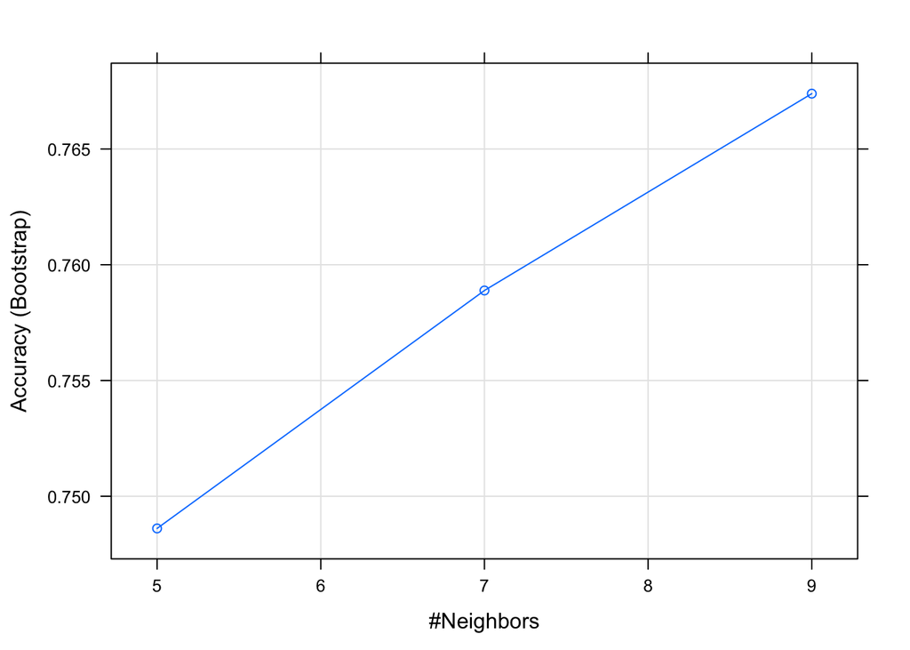

```r
# LOAD PACKAGES ############################################ caret

# LOAD DATA ################################################ Read CSV df_big
# <- read.csv(here::here('content','tutorial', 'data', 'ccdefault.csv'),
# header = T) I want a smaller dataset df<-
# df_big[sample(nrow(df_big),replace=F,size=0.05*nrow(df_big)),]

# NORMALIZE ################################################ Apply function
# to data frame (but not index or outcome) dfn <- as.data.frame(lapply(df[,
# 2:24], normalize)) head(dfn)

# Put outcome variable back on and rename
dfn <- cbind(dfn, df[, 25])
names(dfn)[24] <- "DEFAULT"

# LABEL must be a factor
dfn$DEFAULT <- as.factor(dfn$DEFAULT)


# Create index to split based on labels
index <- caret::createDataPartition(dfn$DEFAULT, p = 0.75, list = FALSE)

# Subset training set with index
dfn.training <- dfn[index, ]

# Subset test set with index
dfn.test <- dfn[-index, ]

# ========= TRAIN MODEL ################################################
# Overview of algos supported by caret names(getModelInfo())

# Train a model
model_knn <- caret::train(dfn.training[, 1:23], dfn.training[, 24], method = "knn")

# How many k did caret use?
model_knn  # 9
model_knn$bestTune
# Use plots to see optimal number of clusters: Plotting yields Number of
# Neighbours Vs accuracy (based on repeated cross validation)
plot(model_knn)
```

```r
# PREDICT ################################################ Predict the
# labels of the test set
predictions <- predict.train(object = model_knn, dfn.test[, 1:23], type = "raw")

# Evaluate the predictions
table(predictions)

# Confusion matrix
confusionMatrix(predictions, dfn.test[, 24])
```

### EXE Naive Bayes // Bayesian Classifier

Builds upon Bayes Rule

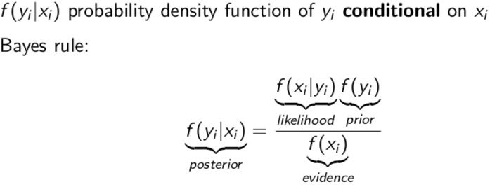

Bayes Rule

(*) The naiveBayes function takes in numeric or factor variables in a data frame or a numeric matrix. It’s important to note that single vectors will not work for the input data but will work for the dependent variable (Y).

```
* Factor variables and Character variables are accepted.
* Character variables are coerced into Factors.
* Numeric variables will be placed on a normal distribution.
* Then the numeric variable will be converted into a probability on that distribution.
```

(*) http://www.learnbymarketing.com/tutorials/naive-bayes-in-r/

```r
## ------------------------------------------------------------------------
SpamData <- read.csv(here::here("SpamData2.csv"))

## ------------------------------------------------------------------------
head(SpamData)
mean(SpamData$Spam)

## ------------------------------------------------------------------------
SpamEmails <- subset(SpamData, Spam == 1)
mean(SpamEmails$exclamation_point == 1)

# Challenge: prove that the maximum likelihood estiamte of θj,y corresponds
# to the proportion of emails in category y that contain the feature j.
# ================ Let’s now run our Bayesian classifier. We will a package
# already implementing a Bayesian classifier in R that will repeat what we
# just did for all the features.

## ------------------------------------------------------------------------
## install.packages('e1071')
library(e1071)

## ------------------------------------------------------------------------
## We will also split our sample into training and testing data:

# install.packages('caTools')
library(caTools)
SpamData$sample <- sample.split(SpamData$Spam, SplitRatio = 0.8)
train = subset(SpamData, SpamData$sample == TRUE)
test = subset(SpamData, SpamData$sample == FALSE)

train <- train[, 1:55]
test <- test[, 1:55]


## ------------------------------------------------------------------------
## We call our naiveBayes function with to estimate the model and we evaluate
## its performance on the testing dataset Create the model on train model <-
## naiveBayes(Class ~ ., data = HouseVotes84)
nB_model <- naiveBayes(as.factor(Spam) ~ ., data = train)

# Predict (using the model) on test
pred_vect <- predict(nB_model, test[, 1:54], type = "class")
table(pred_vect, as.factor(test$Spam), dnn = c("Prediction", "Actual"))

pred_T <- table(pred_vect, as.factor(test$Spam))
pred_T
colnames(pred_T) <- c("predicted non-spam", "predicted spam")
rownames(pred_T) <- c("true non-spam", "true spam")
# make %
pred_T <- pred_T/sum(pred_T)
pred_T

## ------------------------------------------------------------------------
## Precission:
pred_T[2, 2]/(pred_T[2, 2] + pred_T[1, 2])

# Recall
pred_T[2, 2]/(pred_T[2, 2] + pred_T[2, 1])

## Accuracy
pred_T[2, 2] + pred_T[1, 1]
```

# CLUSTER ANALISYS

Clustering is “pragmatic grouping” done for a reason that make sense to me. It is considered `Exploratory Data Mining` bc it helps tease out relationships in large datasets Examples: + marketing segmentation - similar customers + medicine - simiar patients + music - genre on playlist that I want together

ALGORITHMs: + by **distance** (only convex clusters) - euclidean distance - connectivity models - hierarchical diagrams - joining or splitting

- by **distance from centroid** (only convex clusters similar size, you pick k)
  - (mean for every group)
  - k-means clustering
- by **density**
  - connected dense regions in k-dimensions
  - model nonconvex clusters
  - it is possible to sort of ignore outliers
  - hard to describe (by parametric distrib function)
- by **distribution model**
  - clusters as stat distributions
  - (ex. multivariate normal)
  - prone to overfitting
  - good to see correlations b/w attributes in data
  - limited to convex clusters

## Three major kinds of clustering:

1. Hierarchical: Start separate and combine
2. Split into set number of clusters (e.g., kmeans)
3. Dividing: Start with a single group and split

### EXE 1/2 HIERARCHICAL CLUST

- by **distance** (only convex clusters)

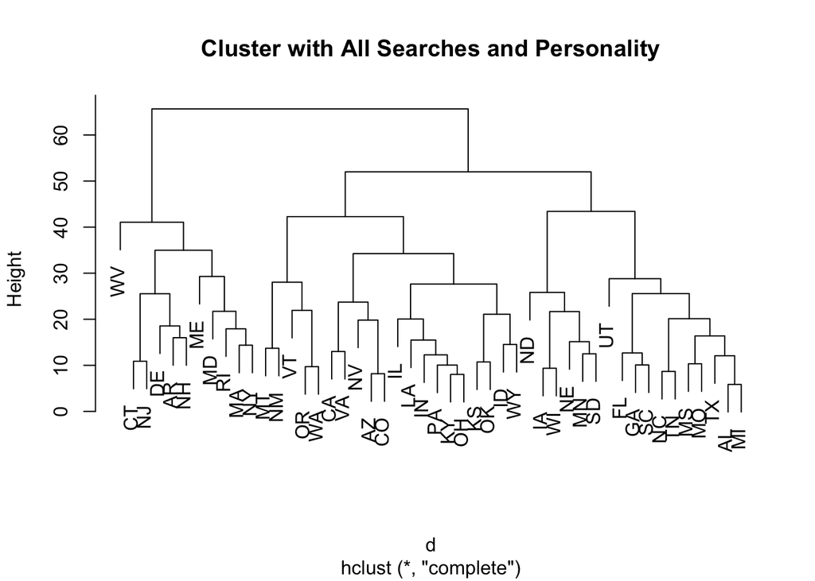

```r
# DM_03_03.R

# LOAD DATA ################################################ POV is where
# .toml is?
states <- read.csv(here::here("ClusterData.csv"), header = T)

colnames(states)

# Save numerical data only
st <- states[, 3:27]
row.names(st) <- states[, 2]
colnames(st)

# Sports search data only
sports <- st[, 8:11]
head(sports)

# CLUSTERING ###############################################

# Create distance matrix
d <- dist(st)

# Hierarchical clustering
c <- hclust(d)
c  # Info on clustering

# Plot dendrogram of clusters
plot(c, main = "Cluster with All Searches and Personality")
```

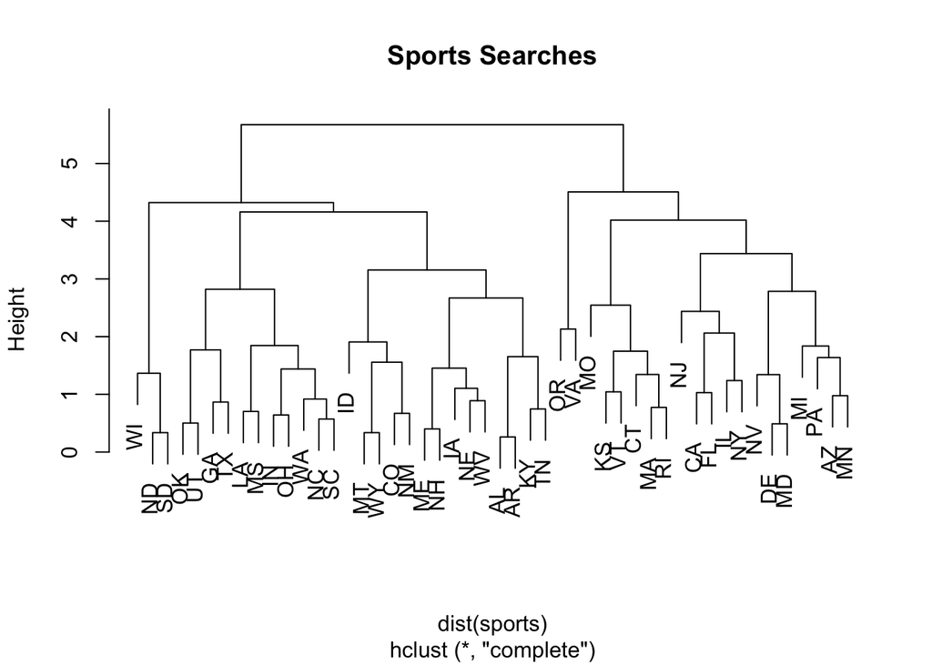

```r
# Or nest commands in one line (for sports data)
plot(hclust(dist(sports)), main = "Sports Searches")
```

### EXE 2/2 hierarchical

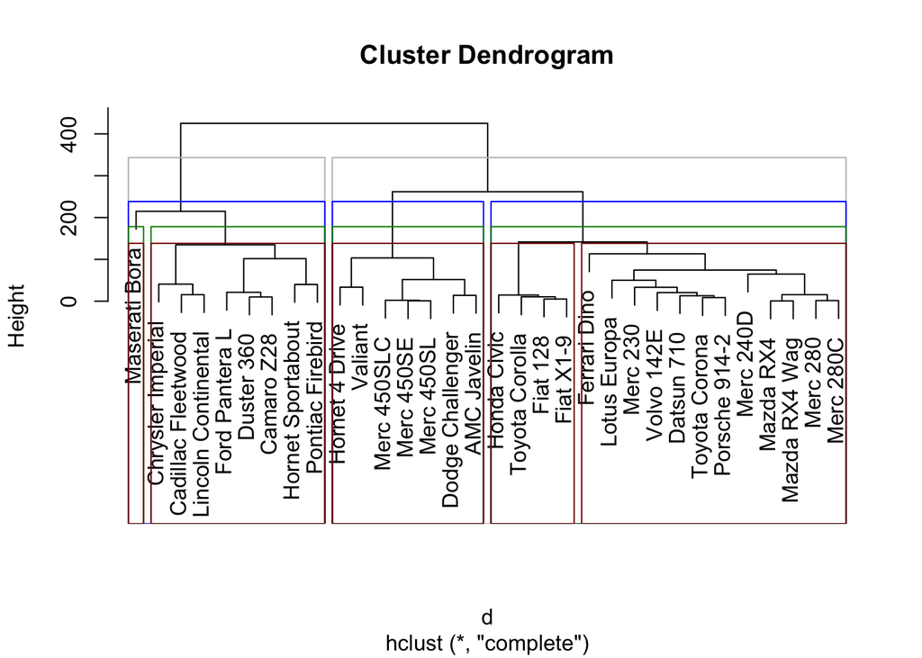

```r
# Conducting a cluster analysis

# Load data ?mtcars
data(mtcars)
mtcars[1:5, ]
mtcars1 <- mtcars[, c(1:4, 6:7, 9:11)]  # Select variables
mtcars1[1:5, ]

# -------- We'll use hierarchical clustering Need distance matrix
# (dissimilarity matrix)
d <- dist(mtcars1)
head(d)  # Huge matrix

# Use distance matrix for clustering
c <- hclust(d)
c

# Plot dendrogram of clusters
plot(c)

# Put observations in groups Need to specify either k = groups or h = height
g3 <- cutree(c, k = 3)  # 'g3' = 'groups 3'
# cutree(hcmt, h = 230) will give same result
g3

# Or do several levels of groups at once 'gm' = 'groups/multiple'
gm <- cutree(c, k = 2:5)  # or k = c(2, 4)
gm

# Draw boxes around clusters
rect.hclust(c, k = 2, border = "gray")
rect.hclust(c, k = 3, border = "blue")
rect.hclust(c, k = 4, border = "green4")
rect.hclust(c, k = 5, border = "darkred")
```

### EXE 1/2 k-means Clustering

- by **distance from centroid** (only convex clusters similar size, you pick k)

`k-means` is on well known *unsupervised* clustering algorithm that finds the minimum total distance of obs. form the centroid of the (best) cluster (for all dimensions)

(*) *hyperparameter* `k` = the number of clusters and has to be set beforehand. k should be picked as a # that is in the bal park of what you are willing to act on (eg. 5 if I want 5 segments of donors)

(*) Where (through an iterative approach) it finds: + The distance between data points within clusters should be as small as possible. + The distance of the centroids (= centres of the clusters) should be as big as possible.

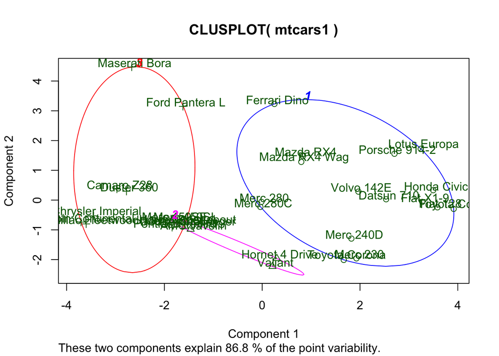

```r
# ======================================================
mtcars1 <- mtcars[, c(1:4, 6:7, 9:11)]  # Select variables

# k-means clustering - I pick 3 clusters
km <- stats::kmeans(mtcars1, centers=3)
km

# Graph based on k-means
require(cluster)
clusplot(mtcars1,  # data frame
         km$cluster,  # cluster data
         color = TRUE,  # color
#          shade = TRUE,  # Lines in clusters
         lines = 3,  # Lines connecting centroids
         labels = 2)  # Labels clusters and cases
```

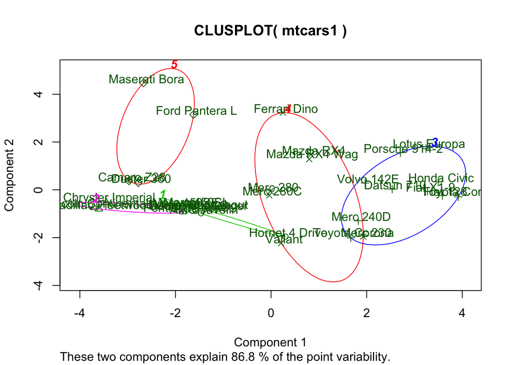

```r
# here I get the centers
km$centers

# here I get the cluster assignment (vector)
km$cluster

# You can evaluate the clusters by looking at $totss and $betweenss.
km$totss
km$withinss # sum of the square of the distance from each data point to the cluster center.  Lower is better. (high withinss would indicate either outliers are in your data or you need to create more clusters.)
km$betweenss # sum of the squared distance between cluster centers.  Ideally you want cluster centers far apart from each other.


# ======================================================
# k-means clustering - I pick 5 clusters
km2 <- kmeans(mtcars1, 5)
km2

# Graph based on k-means
require(cluster)
clusplot(mtcars1,  # data frame
         km2$cluster,  # cluster data
         color = TRUE,  # color
#          shade = TRUE,  # Lines in clusters
         lines = 3,  # Lines connecting centroids
         labels = 2)  # Labels clusters and cases
```

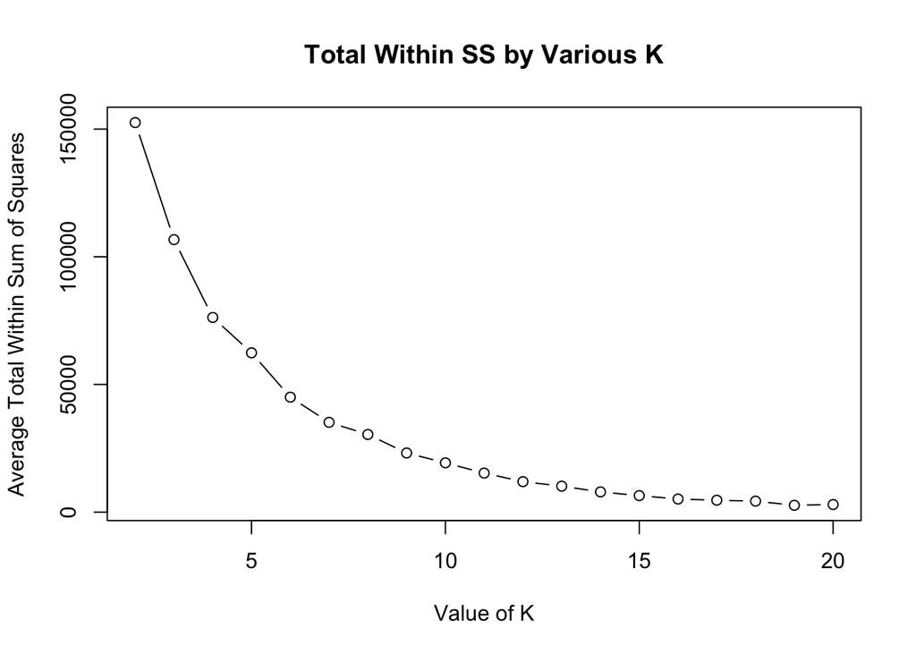

```r
 # here I get the centers
km2$centers

# You can evaluate the clusters by looking at $totss and $betweenss.
km2$totss
km2$withinss # sum of the square of the distance from each data point to the cluster center.  Lower is better. (high withinss would indicate either outliers are in your data or you need to create more clusters.)
km2$betweenss # sum of the squared distance between cluster centers.  Ideally you want cluster centers far apart from each other.


# ======================================================
# Find ideal k
rng<-2:20 #K from 2 to 20
tries <-100 #Run the K Means algorithm 100 times
avg.totw.ss <-integer(length(rng)) #Set up an empty vector to hold all of points

for(v in rng){ # For each value of the range variable
 v.totw.ss <-integer(tries) #Set up an empty vector to hold the 100 tries
 for(i in 1:tries){
 k.temp <-kmeans(mtcars1,centers=v) #Run kmeans
 v.totw.ss[i] <-k.temp$tot.withinss#Store the total withinss
 }
 avg.totw.ss[v-1] <-mean(v.totw.ss) #Average the 100 total withinss
}

plot(rng,avg.totw.ss,type="b", main="Total Within SS by Various K",
 ylab="Average Total Within Sum of Squares",
 xlab="Value of K")
```

```r
# Somewhere around K = 5 we start losing dramatic gains.  So I’m satisfied with 5 clusters.
```

### EXE 2/2 k-means CLUST - THEORY ILLUSTRATION

Building the algorithm http://www.learnbymarketing.com/tutorials/k-means-clustering-in-r-example/ http://blog.ephorie.de/learning-data-science-understanding-and-using-k-means-clustering

Because there are too many possible combinations of all possible clusters comprising all possible data points k-means follows an iterative approach called *expectation-maximization algorithm*.: 1. Initialization: assign clusters randomly to all data points 2. E-step (for expectation): assign each observation to the “nearest” (based on Euclidean distance) cluster 3. M-step (for maximization): determine new centroids based on the mean of assigned objects 4. Repeat steps 3 and 4 until no further changes occur

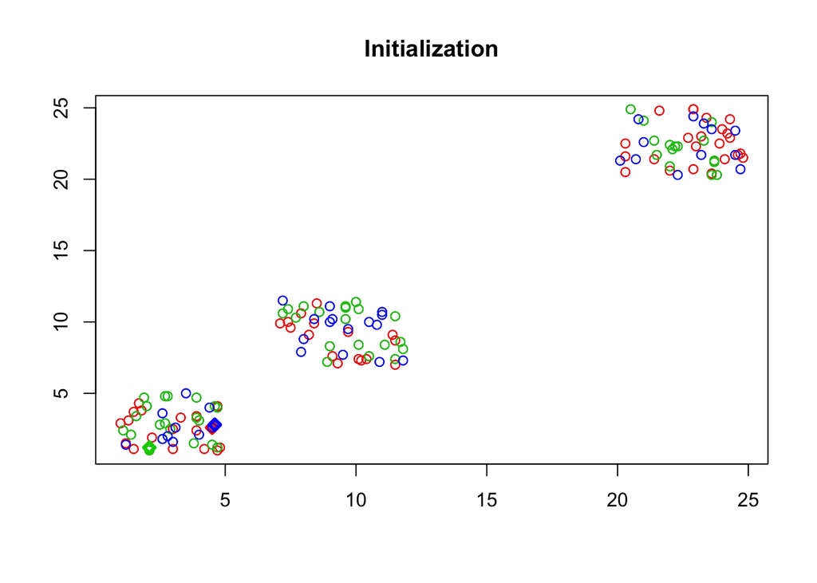

```r
n <- 3  # no. of centroids
set.seed(1415)  # set seed for reproducibility

M1 <- matrix(round(runif(100, 1, 5), 1), ncol = 2)
M2 <- matrix(round(runif(100, 7, 12), 1), ncol = 2)
M3 <- matrix(round(runif(100, 20, 25), 1), ncol = 2)
M <- rbind(M1, M2, M3)

C <- M[1:n, ]  # define centroids as first n objects
obs <- length(M)/2
A <- sample(1:n, obs, replace = TRUE)  # assign objects to centroids at random
colors <- seq(10, 200, 25)

# helper function for plotting the steps
clusterplot <- function(M, C, txt) {
    plot(M, main = txt, xlab = "", ylab = "")
    for (i in 1:n) {
        points(C[i, , drop = FALSE], pch = 23, lwd = 3, col = colors[i])
        points(M[A == i, , drop = FALSE], col = colors[i])
    }
}
clusterplot(M, C, "Initialization")
```

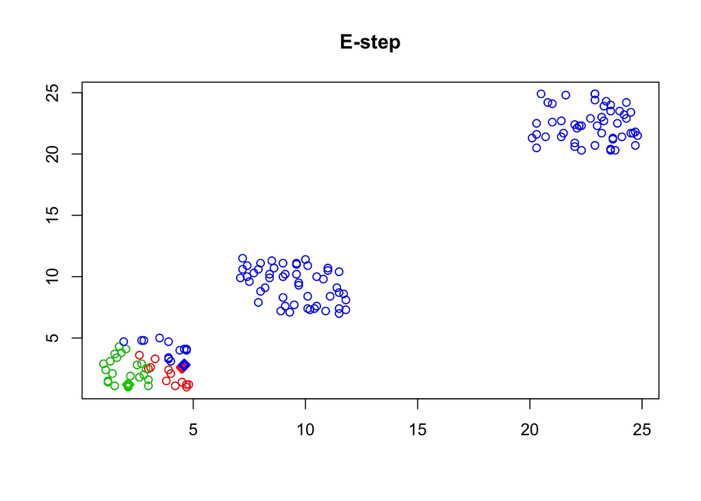

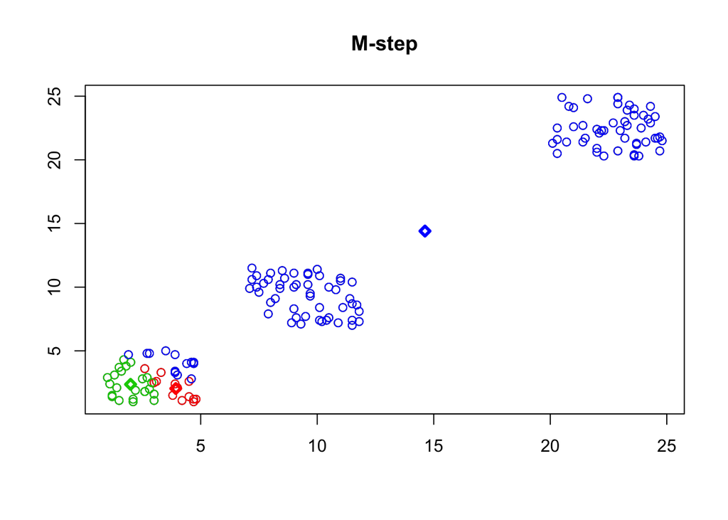

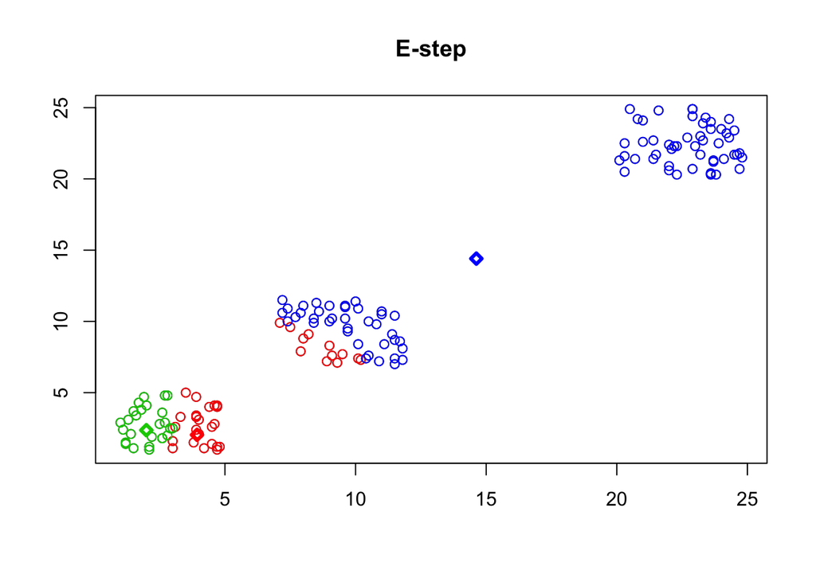

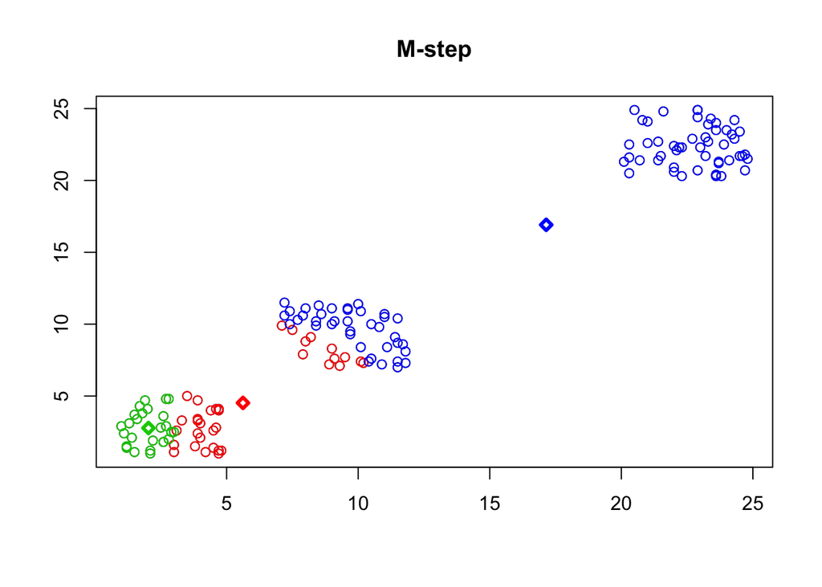

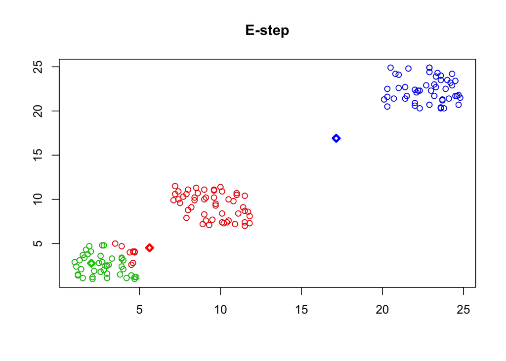

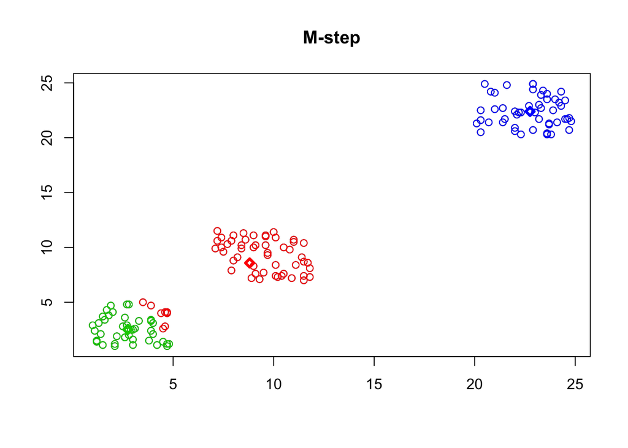

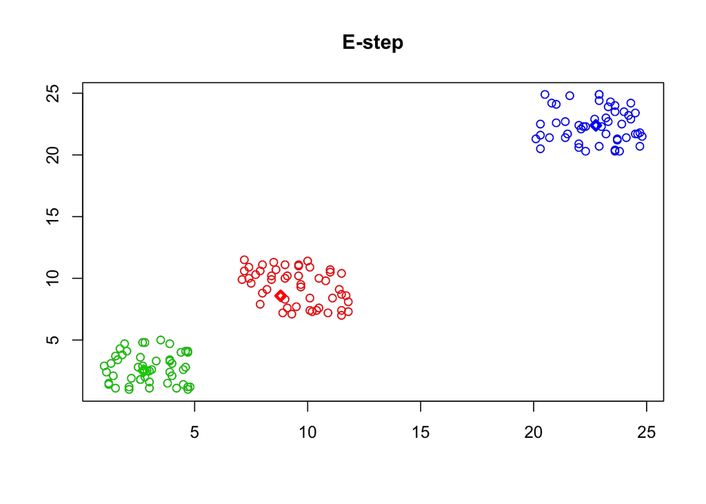

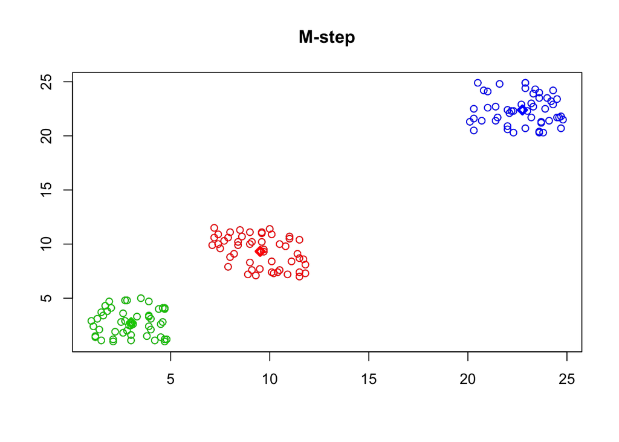

```r
#------------k-means algorithm iterative
# diamonds are the Centroids

repeat {
    # calculate Euclidean distance between objects and centroids
    D <- matrix(data = NA, nrow = n, ncol = obs)
    for (i in 1:n) {
        for (j in 1:obs) {
            D[i, j] <- sqrt((M[j, 1] - C[i, 1])^2 + (M[j, 2] - C[i, 2])^2)
        }
    }
    O <- A

    ## E-step: parameters are fixed, distributions are optimized
    A <- max.col(t(-D))  # assign objects to centroids
    if (all(O == A))
        break  # if no change stop
    clusterplot(M, C, "E-step")

    ## M-step: distributions are fixed, parameters are optimized determine new
    ## centroids based on mean of assigned objects
    for (i in 1:n) {
        C[i, ] <- apply(M[A == i, , drop = FALSE], 2, mean)
    }
    clusterplot(M, C, "M-step")
}
```

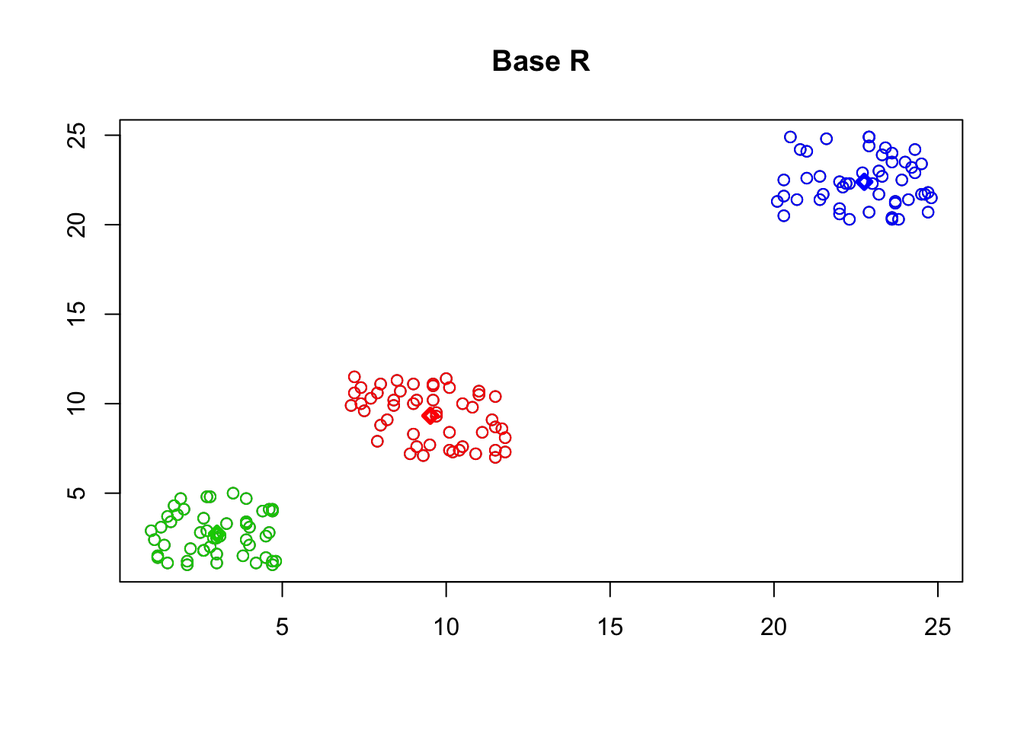

```r
# Check results
(custom <- C[order(C[, 1]), ])
## [,1] [,2] [1,] 3.008 2.740 [2,] 9.518 9.326 [3,] 22.754 22.396


#------------k-means algorithm BASE R
cl <- kmeans(M, n)
clusterplot(M, cl$centers, "Base R")
```

```r
# Check results
(base <- cl$centers[order(cl$centers[, 1]), ])
## [,1] [,2] 2 3.008 2.740 1 9.518 9.326 3 22.754 22.396

# same!
```

### RESOURCES

- http://www.learnbymarketing.com/tutorials/
- https://www.linkedin.com/learning/r-statistics-essential-training/computing-a-bivariate-regression (Linkedin Premium)
- https://www.linkedin.com/learning/data-science-foundations-data-mining/anomaly-detection-in-r (Linkedin Premium)
- IADB ML course
- Hastie, Tibshirani, Firedman “The elements of Statistical Learning”, 2009